# Broad-sense heritability estimates

Juliette Archambeau

14 novembre, 2020

In this document, we calculate the broad-sense heritability $H^{2}$ based on models M1 and M5, such as:

$$H^{2} = \frac{Var_{genotype}}{Var_{genotype} + Var_{residual}}$$

```r
source("../../scripts/Functions/vir_lite.R")
square <- function(x) (x*x)

# Parameters of the funtion vir_lite
ds=0.7
```

The credible intervals used are 95% CI.

```r
prob=0.95
probs <- c((1 - prob) / 2, 1 - (1 - prob) / 2)
```

Train dataset of P1 partition:

```r
data <- readRDS(file="../../data/TrainP1.RDS")
```

# 1 **Model M1**

```r
mod <- readRDS(file="../../outputs/models/P1/MOD1.rds")
```

## 1.1 Residual variance

There are two ways of computing the residual variance. See [Bayesian R2 and LOO-R2 by *Aki Vehtari, Andrew Gelman, Ben Goodrich, Jonah Gabry*](https://avehtari.github.io/bayes_R2/bayes_R2.html) from which the mathematical formulas and the codes come from.

First, we can calculate the residual variance using residuals draws from the residual distribution, which is obtained:

$$Var_{res} = Var_{n=1}^{N} \hat{e}_{n}$$
where $\hat{e}_{n} = y_{n} - \hat{y}_{n}$

```r
y <- mod$data$`log(height)`
ypred <- pp_expect(mod, transform = TRUE)
```

```r
e <- -1 * sweep(ypred, 2, y)
var_e <- apply(e, 1, var)
data.frame(Parameter="$Var_{e}$",
           Median=median(var_e),
           SD=sd(var_e),
           LowCI=HPDI(var_e,prob=0.95)[[1]],
           SudCI=HPDI(var_e,prob=0.95)[[2]]) %>%
  knitr::kable(digits = 4 ,format = "markdown")
```

| Parameter | Median | SD | LowCI | SudCI |
| --- | --- | --- | --- | --- |
| $Var_{e}$ | 0.0981 | 1e-04 | 0.0978 | 0.0983 |

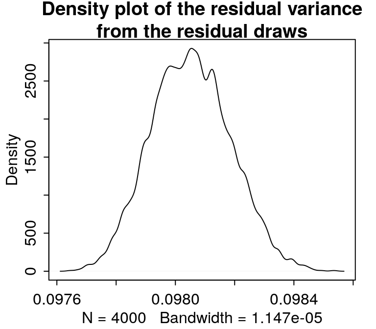

The second way to obtain the residual variance is by using draws from the modeled (approximate) residual variance. For linear regression, the residual variance can thus be defined as:

$$Var_{res} = \sigma^{2}$$

```r
sigma2 <- as.matrix(mod, pars = c("sigma"))^2
data.frame(Parameter="$\\sigma^{2}$",
           Median=median(sigma2),
                  SD=sd(sigma2),
                  LowCI=HPDI(sigma2,prob=0.95)[[1]],
                  SudCI=HPDI(sigma2,prob=0.95)[[2]]) %>%
  knitr::kable(digits = 4 ,format = "markdown")
```

| Parameter | Median | SD | LowCI | SudCI |
| --- | --- | --- | --- | --- |
| $\sigma^{2}$ | 0.098 | 9e-04 | 0.0963 | 0.0998 |

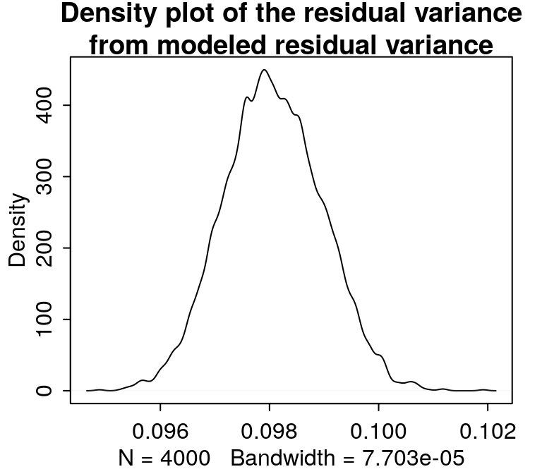

```r
var_res <- sigma2
```

## 1.2 Variance between genotypes

```r
var_gen <- as.matrix(mod, pars = c("sd_prov:clon__Intercept"))^2
data.frame(Parameter="$Var_{genotype}$",
           Median=median(var_gen),
                  SD=sd(var_gen),
                  LowCI=HPDI(var_gen,prob=0.95)[[1]],
                  SudCI=HPDI(var_gen,prob=0.95)[[2]]) %>%
  knitr::kable(digits = 4 ,format = "markdown")
```

| Parameter | Median | SD | LowCI | SudCI |
| --- | --- | --- | --- | --- |
| $Var_{genotype}$ | 0.0116 | 9e-04 | 0.01 | 0.0134 |

## 1.3 Broad-sense heritability

```r
heritability <- var_gen / (var_gen + var_res)
data.frame(Parameter="$H^{2}$",
           Median=median(heritability),
                  SD=sd(heritability),
                  LowCI=HPDI(heritability,prob=0.95)[[1]],
                  SudCI=HPDI(heritability,prob=0.95)[[2]]) %>%
  knitr::kable(digits = 4 ,format = "markdown")
```

| Parameter | Median | SD | LowCI | SudCI |
| --- | --- | --- | --- | --- |
| $H^{2}$ | 0.1054 | 0.0072 | 0.0909 | 0.1193 |

# 2 **Model M5**

```r
mod <- readRDS(file="../../outputs/models/P1/MOD5.rds")
```

## 2.1 Residual variance

Residual variance using draws from the residual distribution:

```r
y <- mod$data$`log(height)`
ypred <- pp_expect(mod, transform = TRUE)
e <- -1 * sweep(ypred, 2, y)
var_e <- apply(e, 1, var)
data.frame(Parameter="$Var_{e}$",
           Median=median(var_e),
           SD=sd(var_e),
           LowCI=HPDI(var_e,prob=0.95)[[1]],
           SudCI=HPDI(var_e,prob=0.95)[[2]]) %>%
  knitr::kable(digits = 4 ,format = "markdown")
```

| Parameter | Median | SD | LowCI | SudCI |
| --- | --- | --- | --- | --- |
| $Var_{e}$ | 0.0976 | 1e-04 | 0.0973 | 0.0979 |

Residual variance using the modeled residual variance:

```r
sigma2 <- as.matrix(mod, pars = c("sigma"))^2
data.frame(Parameter="$\\sigma^{2}$",
           Median=median(sigma2),
           SD=sd(sigma2),
           LowCI=HPDI(sigma2,prob=0.95)[[1]],
           SudCI=HPDI(sigma2,prob=0.95)[[2]]) %>%
  knitr::kable(digits = 4 ,format = "markdown")
```

| Parameter | Median | SD | LowCI | SudCI |
| --- | --- | --- | --- | --- |
| $\sigma^{2}$ | 0.0976 | 9e-04 | 0.0958 | 0.0992 |

```r
var_res <- sigma2
```

## 2.2 Gene-pool specific heritability

```r
# Northern-Africa gene pool
var_gen <- as.matrix(mod, pars = c("sd_clon1__Intercept"))^2
heritability <- var_gen / (var_gen + var_res)
df <- data.frame(Median=mean(heritability),
                 SD=sd(heritability),
                 InfCI=HPDI(heritability,prob=0.95)[[1]],
                 SupCI=HPDI(heritability,prob=0.95)[[2]])
row.names(df) <- "hNA"
hNA <- heritability[,1]

# Corsican gene-pool
var_gen <- as.matrix(mod, pars = c("sd_clon2__Intercept"))^2
heritability <- var_gen / (var_gen + var_res)
df["hC",] <- c(mean(heritability),
               sd(heritability),
               HPDI(heritability,prob=0.95)[[1]],
               HPDI(heritability,prob=0.95)[[2]])
hC <- heritability[,1]

# Central Spain gene pool
var_gen <- as.matrix(mod, pars = c("sd_clon3__Intercept"))^2
heritability <- var_gen / (var_gen + var_res)
df["hCS",] <- c(mean(heritability),
               sd(heritability),
               HPDI(heritability,prob=0.95)[[1]],
               HPDI(heritability,prob=0.95)[[2]])
hCS <- heritability[,1]

# French Atlantic gene pool
var_gen <- as.matrix(mod, pars = c("sd_clon4__Intercept"))^2
heritability <- var_gen / (var_gen + var_res)
df["hFA",] <- c(mean(heritability),
               sd(heritability),
               HPDI(heritability,prob=0.95)[[1]],
               HPDI(heritability,prob=0.95)[[2]])
hFA <- heritability[,1]

# Iberian Atlantic gene pool
var_gen <- as.matrix(mod, pars = c("sd_clon5__Intercept"))^2
heritability <- var_gen / (var_gen + var_res)
df["hIA",] <- c(mean(heritability),
               sd(heritability),
               HPDI(heritability,prob=0.95)[[1]],
               HPDI(heritability,prob=0.95)[[2]])
hIA <- heritability[,1]

# South-eastern Spain gene pool
var_gen <- as.matrix(mod, pars = c("sd_clon6__Intercept"))^2
heritability <- var_gen / (var_gen + var_res)
df["hSES",] <- c(mean(heritability),
               sd(heritability),
               HPDI(heritability,prob=0.95)[[1]],
               HPDI(heritability,prob=0.95)[[2]])
hSES <- heritability[,1]
```

```r
df <- df %>% mutate(Parameter = recode_factor(rownames(df),
                              'hNA'='$H^{2}_{NA}$',
                              'hC'='$H^{2}_{C}$',
                              'hCS'='$H^{2}_{CS}$',
                              'hFA'='$H^{2}_{FA}$',
                              'hIA'='$H^{2}_{IA}$',
                              'hSES'='$H^{2}_{SES}$')) %>%  remove_rownames() %>%
  dplyr::select(Parameter,Median,SD,InfCI,SupCI)


df %>% knitr::kable(digits = 3 ,format = "markdown")
```

| Parameter | Median | SD | InfCI | SupCI |
| --- | --- | --- | --- | --- |
| $H^{2}_{NA}$ | 0.141 | 0.064 | 0.034 | 0.266 |
| $H^{2}_{C}$ | 0.210 | 0.057 | 0.107 | 0.322 |
| $H^{2}_{CS}$ | 0.152 | 0.020 | 0.114 | 0.190 |
| $H^{2}_{FA}$ | 0.136 | 0.017 | 0.105 | 0.169 |
| $H^{2}_{IA}$ | 0.104 | 0.021 | 0.065 | 0.146 |
| $H^{2}_{SES}$ | 0.223 | 0.070 | 0.093 | 0.363 |

```r
print(xtable(df, type = "latex",digits=3), file = paste0("../../tables/Posteriors/M5_HeritabilityEstimates.tex"), include.rownames=FALSE,sanitize.text.function = function(x) {x})
```

```r
POST <- data.frame(genepool=c(rep("hNA",6000),rep("hC",6000),rep("hCS",6000),rep("hFA",6000),rep("hIA",6000),rep("hSES",6000)),
                   value=c(hNA,hC,hCS,hFA,hIA,hSES))

POST <- POST %>%   group_by(genepool) %>%
  dplyr::mutate(meanpergenepool = mean(value))%>%
  ungroup()


p <- ggplot()+
  geom_vline(xintercept = 0, col        = "grey70") +
  geom_density_ridges(data  = POST,
                                aes(x      = value,
                                    y      = reorder(as.factor(genepool), meanpergenepool),
                                    fill   = as.factor(genepool), vline_color = ..quantile..),
                                scale = 1,
                                alpha = .6,
                                rel_min_height=c(.006),
                                size=0.8,
                                quantile_lines = TRUE, quantiles = c(0.025,0.5,0.975)) +

  scale_discrete_manual("vline_color",
                        values = c("blue", "red", "blue", "black"),
                        breaks = c(1, 2),
                        labels = c("5th & 95th percentiles", "Median"),
                        name = NULL) +

  scale_fill_manual(values=c("gold2","darkorchid3","navyblue","turquoise2","orangered3","green3"),
                    labels = c("Corsica (C)",
                               "Central Spain (CS)",
                               "French Atlantic (FA)",
                               "Iberian Atlantic (IA)",
                               "Northern Africa (NA)",
                               "South-eastern Spain (SES)"),
                    name="Gene pools:") +

    scale_y_discrete(labels=c("hNA"=parse(text = TeX("$H_{NA}^{2}$")),
                            "hC"=parse(text = TeX("$H_{C}^{2}$")),
                            "hCS"=parse(text = TeX("$H_{CS}^{2}$")),
                            "hFA"=parse(text = TeX("$H_{FA}^{2}$")),
                            "hIA"=parse(text = TeX("$H_{IA}^{2}$")),
                            "hSES"=parse(text = TeX("$H_{SES}^{2}$")))) +
  labs(y  = "",
       x  = TeX("Gene-pool specific broad-sense heritability estimates")) +

  theme_bw() +
  theme(axis.text = element_text(size=18),
        axis.title = element_text(size=18),
        legend.text = element_text(size=18,margin = margin(t = 10)),
        legend.title = element_text(size=20),
        legend.spacing.y = unit(1, 'cm'))
```

> Partial genetic values

```r
clon1 <- tidy(mod,parameters="r_clon1", intervals = FALSE)
clon1$clon <- str_sub(clon1$term,9,-12)
clon1$term <- NULL
colnames(clon1) <- c("est1","std1","clon")

clon2 <- tidy(mod,parameters="r_clon2", intervals = FALSE)
clon2$clon <- str_sub(clon2$term,9,-12)
clon2$term <- NULL
colnames(clon2) <- c("est2","std2","clon")

clon3 <- tidy(mod,parameters="r_clon3", intervals = FALSE)
clon3$clon <- str_sub(clon3$term,9,-12)
clon3$term <- NULL
colnames(clon3) <- c("est3","std3","clon")

clon4 <- tidy(mod,parameters="r_clon4", intervals = FALSE)
clon4$clon <- str_sub(clon4$term,9,-12)
clon4$term <- NULL
colnames(clon4) <- c("est4","std4","clon")

clon5 <- tidy(mod,parameters="r_clon5", intervals = FALSE)
clon5$clon <- str_sub(clon5$term,9,-12)
clon5$term <- NULL
colnames(clon5) <- c("est5","std5","clon")

clon6 <- tidy(mod,parameters="r_clon6", intervals = FALSE)
clon6$clon <- str_sub(clon6$term,9,-12)
clon6$term <- NULL
colnames(clon6) <- c("est6","std6","clon")

ps <- data %>% dplyr::select(clon,Q1,Q2,Q3,Q4,Q5,Q6,max.Qvalue,max.Q) %>%  distinct()

g <- Reduce(
  function(x, y, ...) merge(x, y, ...),
  list(clon1,clon2,clon3,clon4,clon5,clon6,ps)
)

g <- g %>% dplyr::select(starts_with("est"),clon,max.Q) %>%
  pivot_longer(-c(clon,max.Q),names_to="PBV",values_to="est")


pPBV <- ggplot(g, aes(x=max.Q, y=est, fill=PBV)) +
   geom_boxplot(alpha=0.6) + theme_bw() +
  scale_x_discrete(labels=c("Q1"="Northern Africa",
                            "Q2"="Corsica",
                            "Q3"="Central Spain",
                            "Q4"="French Atlantic",
                            "Q5"="Iberian Atlantic",
                            "Q6"="South-eastern Spain")) +
  scale_fill_manual(values=c("orangered3","gold2","darkorchid3","navyblue","turquoise2","green3"),
                    labels = c("Northern Africa",
                               "Corsica",
                               "Central Spain",
                               "French Atlantic",
                               "Iberian Atlantic",
                               "South-eastern Spain"),
                    name=TeX("Gene pools\ncontributing to the\npartial genetic values:")) +
  labs(y        = "Means of the posterior distribution\nof the genetic values",
       x        = TeX("Dominant gene pool for each genotype")) +
  theme(axis.text = element_text(size=14.5),
        axis.title = element_text(size=20),
        legend.text = element_text(size=18),
        legend.title = element_text(size=20))
```

> Figure in the manuscript

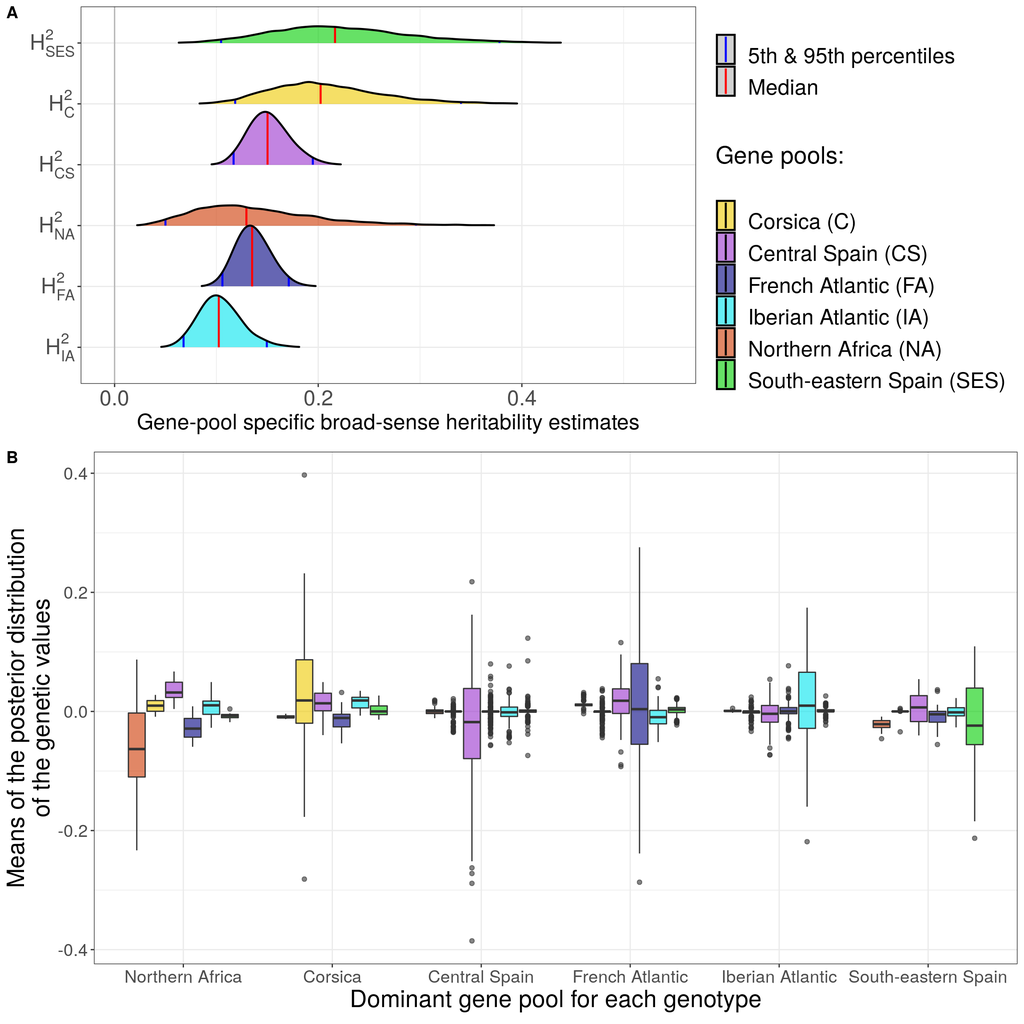

```r
pPBVf <- pPBV + theme(legend.position = "none")

pp <-  ggarrange(p,pPBVf,labels=c("A","B"),nrow=2,heights = c(1, 1.3))
ggsave(pp,file="../../figs/manuscript/heritabilityM5.png",height=12,width=12)
pp
```